# Homework 2.1

- Show All Code
- Hide All Code
- View Source

Author

Affiliation

David Sneddon

Old Dominion University

## Question 1

1. I send out a survey to individuals who graduated from ODU. I ask them to report their salary. Most people fill out the salary question, but some people leave it blank. Can I fill in zero for these blanks? Explain why or why not. (**4 Points**)

This would be a faulty assumption. Salary is a ratio measurement which has a natural zero. Since a zero entered for salary would mean the person has a salary of zero. This is different than no value for salary, the actual value of which could be anything. Arbitrarily entering “0” for an NA value would skew the sample.

2. Suppose I decided to pick students with ID numbers that end in an 8 to survey. I calculate the mean salary of those who submitted salaries. Will this average salary be representative of all ODU students? Explain why or why not. (**4 Points**)

This sample would be representative of all ODU students assuming the final digit in ODU student numbers is random and “all ODU students” is meant as “all ODU graduates”. By design we are collecting data for ODU graduates, so ODU students that do not go on to graduate from ODU due to transfer or otherwise would not be represented.

3. Continuing from above, if you think think the salary will be representative, explain a way one could survey students where the resulting average *would not* be representative. If you think the above salary will not be representative, explain a way one could survey students where the resulting average *would* be representative. (**4 Points**)

To make the the result not representative of all ODU (bachelor’s graduates?) you could choose to only survey Strome graduates. Or only survey graduates that graduated within a short time frame, as time since graduation would be endogenous to salary. On the other hand, by not limiting to a time frame there is the possibility of heteroscedacity being introduced.

4. Why do we use the sum of squared differences when calculating dispersion? (**4 Points**)

The sum of deviations from the mean is always zero. The square of the deviation increases exponentially as the deviation increases thereby making dispersion measurable.

## Question 2

Use the state-year cigarette panel data from the previous module ([data](https://vincentarelbundock.github.io/Rdatasets/csv/Ecdat/Cigar.csv); [documentation](https://vincentarelbundock.github.io/Rdatasets/doc/Ecdat/Cigar.html)) for this question.

1. Read in the data, and present summary statistics for price, population, cpi, disposable income, and cigarette sales. Include the number of observations, mean, standard deviation, minimum and maximum. Use the package(s) from the course notes. (**8 Points**)

```r
##I copy pasted this from course notes
# use this every time you want to use 'modelsummary'
library("modelsummary")
# add this line when loading 'modelsummary', too
options("modelsummary_factory_default" = "kableExtra")
####################################################
#Read in the data
cig_data <- read.csv("https://vincentarelbundock.github.io/Rdatasets/csv/Ecdat/Cigar.csv")
#Formatting
title <- "Cigarette Data - Summary Statistics"
frmla <- (`Price` = price) + (`CPI` = cpi) + (`Disposable Income per captia` = ndi) + (`Cigarette Sales` = sales) ~ (`N` = length) + Mean + (`St. Dev.` = sd) + (`Min` = min) + (`Max` = max)
#Output a table
datasummary(frmla, data = cig_data, title = title, fmt = fmt_significant(2))
```

Cigarette Data - Summary Statistics

|  | N | Mean | St. Dev. | Min | Max |
| --- | --- | --- | --- | --- | --- |
| Price | 1380 | 69 | 42 | 23 | 202 |
| CPI | 1380 | 74 | 37 | 31 | 140 |
| Disposable Income per captia | 1380 | 7525 | 4748 | 1323 | 23074 |
| Cigarette Sales | 1380 | 124 | 31 | 53 | 298 |

2. Write your own function to calculate a weighted average. As a hint, your function should accept two arguments: one for values and one for weights. (**4 Points**)

```r
#Declares a function that accepts a value vector and a weight vector and returns a weigthed average
wtdmean <- function(val,wt){
    valwt <- val
  for (i in 1:length(val)){
    valwt[i] <- as.numeric(valwt[i]) * as.numeric(wt[i])
    }
  return((sum(valwt))/(sum(wt)))
}
```

3. Use your function to find the population-weighted average of income. Aside from the formulas being different, provide an intuitive explanation for the difference you observe between the weighted average and the simple average. (**4 Points**)

```r
#In this implementation the function multiplies income per capita times the population sums all elements then divides by total population.
wtdmean(cig_data$ndi, cig_data$pop)
```

**Output**

```
[1] 8327.552
```

This produces an average where higher populations have a higher impact on the mean income. As the income measure is per capita, this gives a closer approximation of the average income of the sample.

4. Produce a visualization of the distribution of cigarette pack prices. Include a vertical, dashed, and colored (you may choose the color) line representing the mean price. Be sure to label the axes, etc. Provide a short description of what you see. (**5 Points**)

```r
#Plots the distribution but rounds of by 10's
plot(table(round(cig_data$price/10)*10),
       main="Distribution of Cigarette Prices",
       xlab="Price",
       ylab="Frequency",
       las=1)
#Draws a vertical red dotted line that represents the mean of the sample
abline(v=mean(cig_data$price),
       lwd=3,
       col="red",
       lty=2)
#Labels the mean
text(x=mean(cig_data$price)-2.5,
     y=250,
     srt=90,
     col="red",
     bquote(bar(X) * " = " *.(round(mean(cig_data$price),digits=1))),
     cex=0.75)
```

**Plot**

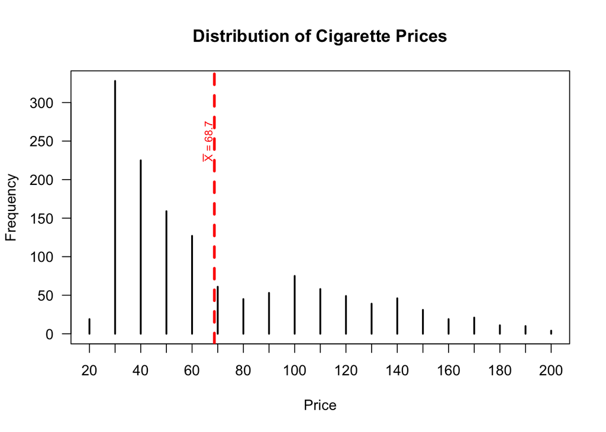

```r
cat("Standard Deviation above the Mean: ",sd(cig_data$price[cig_data$price>mean(cig_data$price)]),"\n")
cat("Standard Deviation below the Mean: ",sd(cig_data$price[cig_data$price<mean(cig_data$price)]))
```

**Output**

```
Standard Deviation above the Mean:  30.86711
Standard Deviation below the Mean:  11.93916
```

5. Produce a scatterplot of price ($X$) vs minimum price of adjoining states ($Y$). Use filled in circles as the point type. Color the points based on whether price is greater than the minimum price of adjoining states. Be sure to label the axes, etc. (**5 Points**)

```r
#Creates a column in cig_data that assigns a color for the point based on the conditions
for (i in 1:length(cig_data$price)){
  ifelse(cig_data$price[i] >= cig_data$pimin[i],
         cig_data$color[i] <- "blue",
         cig_data$color[i] <- "green")
  }
#Plots the data
plot(cig_data$price, cig_data$pimin,
     col = cig_data$color,
     pch = 20,
     cex = 0.5,
     main = "Cigarette Prices vs Adjoining State Minimum Prices",
     xlab = "Price",
     ylab = "Adjoining State Mininmum")
#Adds a legend
legend("bottomright",
       pch = 19,
       bty = "o",
       cex = 0.75,
       horiz = FALSE,
       legend = c("At or above adjoining state min.","Below adjoining state min."),
       col = c("blue","green"))
```

**Plot**

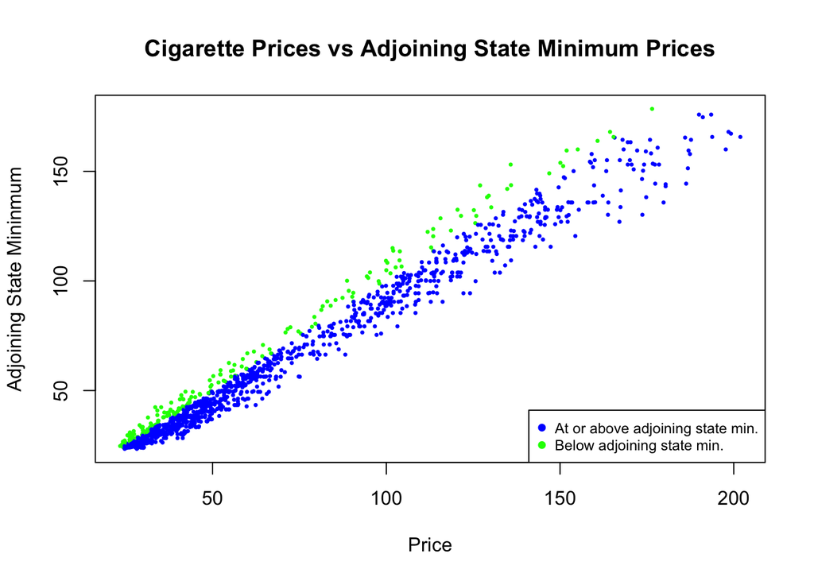

```r
#Creates a column for a four digit year, luckily the data is all from the 20th century
cig_data$yyyyear <- as.numeric(paste0("19",cig_data$year))
#Creates an invisible plot of the data
plot(cig_data$yyyyear, cig_data$sales,
     las = 1,
     type = "n",
     xlab = "Year",
     ylab = "Per Capita Cigarette Sales"
     )
#Adds time series lines for each state with different colors. Willing to bet this is the exact implementation in the prompt, or at least close to it since the colors even match.
for (i in unique(cig_data$state)){
  lines(cig_data$yyyyear[cig_data$state==i],
        cig_data$sales[cig_data$state==i],
        col = i)
}
#Not really a legend, more of a title
 legend("topright",
       legend = "State by Year",
       cex = 0.75,
       bty = "n")
 abline(v=1980,
       lwd=1,
       lty=2)
#Nailed it.
```

**Plot**

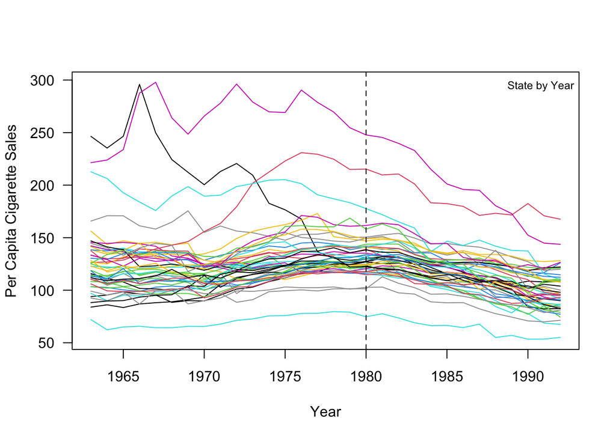

It really wasn’t that hard. I was subsetting by year in the for loop instead of state for a bit, and wondering why it was going so wrong. Then I changed it to state and everything came out OK!